# Lista 2 Computacional

Davi Wentrick Feijó - 200016806

2023-06-19

#### Questao 1)

Considere o modelo
$$\begin{align*}
Y_{ij} & \sim \text{Poisson}(\lambda_{ij}) \\
\lambda_{ij} & = \exp{(\alpha + \beta t_i)},
\end{align*}$$
onde $Y_{ij}$ representa o número de montanhistas que atingiram o cume pela rota $j$ no dia $i$, $\alpha$ e $\beta$ são parâmetros desconhecidos do modelo e $t_i$ indica a temperatura média no dia $i$. Para uma determinada temperatura, o modelo prevê o mesmo valor para todas as rotas. Desconsidere os dados da rota *glacier only - no summit attempt*. Por fim, note que para obter o valor de $y_{ij}$ é preciso somar todos os sucessos registrados no dia $i$ para a rota $j$.

```r
set.seed(420)
#Organizando o banco de dados
climbing <- read_csv("climbing_statistics.csv")
weather <- read_csv("Rainier_Weather.csv")
convert <-function(x) (x-32) * 5/9
shift <-function(x) x - mean(x)
dados <- inner_join(climbing, weather) %>%
  select(-matches("Percent|Battery")) %>%
  filter(Attempted >= Succeeded) %>%
  mutate(`Temperature AVG`= convert(`Temperature AVG`),
         Cleaver = Route =="Disappointment Cleaver",
         Date = lubridate::mdy(Date)) %>%
  select(Date, Succeeded, everything()) %>%
  rename(Data = Date,
         Sucessos = Succeeded,
         Tentativas = Attempted,
         Temperatura =`Temperature AVG`,
         Umidade_relativa =`Relative Humidity AVG`,
         Velocidade_vento =`Wind Speed Daily AVG`,
         Direc_vento =`Wind Direction AVG`,
         Radiacao_solar =`Solare Radiation AVG`)

# Agrupando por dia e rota e desconsiderando a rota
dados2 <- dados %>% group_by(Data,Route) %>%
  mutate(Sucessos = sum(Sucessos),
         Tentativas = sum(Tentativas),
         Cleaver = case_when(Cleaver == T ~ 1,
                             T ~ 0)) %>%
  summarise_if(is.numeric,mean) %>%
  filter(Route != "glacier only - no summit attempt")
```

```r
head(climbing)
```

```
## # A tibble: 6 × 5
##   Date       Route                  Attempted Succeeded `Success Percentage`
##   <chr>      <chr>                      <dbl>     <dbl>                <dbl>
## 1 11/27/2015 Disappointment Cleaver         2         0                    0
## 2 11/21/2015 Disappointment Cleaver         3         0                    0
## 3 10/15/2015 Disappointment Cleaver         2         0                    0
## 4 10/13/2015 Little Tahoma                  8         0                    0
## 5 10/9/2015  Disappointment Cleaver         2         0                    0
## 6 10/3/2015  Disappointment Cleaver        10         0                    0
```

```r
head(weather)
```

```
## # A tibble: 6 × 7
##   Date       `Battery Voltage AVG` `Temperature AVG` `Relative Humidity AVG`
##   <chr>                      <dbl>             <dbl>                   <dbl>
## 1 12/31/2015                  13.8             19.1                     21.9
## 2 12/30/2015                  13.8             14.6                     18.5
## 3 12/29/2015                  13.8              6.61                    34.1
## 4 12/28/2015                  13.7              8.69                    70.6
## 5 12/27/2015                  13.4             14.1                     95.8
## 6 12/26/2015                  13.5             17.5                     47.6
## # ℹ 3 more variables: `Wind Speed Daily AVG` <dbl>, `Wind Direction AVG` <dbl>,
## #   `Solare Radiation AVG` <dbl>
```

```r
head(dados)
```

```
## # A tibble: 6 × 10
##   Data       Sucessos Route              Tentativas Temperatura Umidade_relativa
##   <date>        <dbl> <chr>                   <dbl>       <dbl>            <dbl>
## 1 2015-11-27        0 Disappointment Cl…          2     -3.15               19.7
## 2 2015-11-21        0 Disappointment Cl…          3     -0.389              21.7
## 3 2015-10-15        0 Disappointment Cl…          2      8.03               27.2
## 4 2015-10-13        0 Little Tahoma               8      4.99               28.3
## 5 2015-10-09        0 Disappointment Cl…          2      3.48               74.3
## 6 2015-10-03        0 Disappointment Cl…         10     -0.0984             62.3
## # ℹ 4 more variables: Velocidade_vento <dbl>, Direc_vento <dbl>,
## #   Radiacao_solar <dbl>, Cleaver <lgl>
```

```r
head(dados2)
```

```
## # A tibble: 6 × 10
## # Groups:   Data [6]
##   Data       Route              Sucessos Tentativas Temperatura Umidade_relativa
##   <date>     <chr>                 <dbl>      <dbl>       <dbl>            <dbl>
## 1 2014-09-23 Disappointment Cl…        0         11       0.476            100
## 2 2014-09-24 Disappointment Cl…        0         12      -1.28             100
## 3 2014-09-25 Disappointment Cl…        8         14      -2.88              99.9
## 4 2014-09-26 Disappointment Cl…       19         41      -2.09             100
## 5 2014-09-27 Disappointment Cl…       25         44       0.733             60.2
## 6 2014-09-28 Disappointment Cl…        6         23       6.13              12.4
## # ℹ 4 more variables: Velocidade_vento <dbl>, Direc_vento <dbl>,
## #   Radiacao_solar <dbl>, Cleaver <dbl>
```

##### a) Conduza um teste de hipóteses por simulação para avaliar a hipótese nula de que a média do número de sucessos obtidos pela rota “Disappointment Cleaver” é igual a média das demais rotas (conjuntamente).

```r
# Número de simulações
n <- 10000

# Arrumando a varaivel Rota
dados3 <- dados2 %>% mutate(Rota = case_when(Route == "Disappointment Cleaver"~"Disappointment Cleaver", T ~ "Demais")) %>%
  select(Sucessos, Rota) %>%
  arrange(Rota)

# Cálculando a diferença absoluta entre as médias dos grupos

diff_media = abs(as.numeric(diff(tapply(dados3$Sucessos,dados3$Rota,mean))))

x <- lapply(1:n, function(a) {
  dados_sinteticos <- dados3
  dados_sinteticos$Sucessos <- sample(dados3$Sucessos, replace = FALSE)
  diff_media_calculada <- abs(as.numeric(diff(tapply(dados_sinteticos$Sucessos,dados_sinteticos$Rota,mean))))
  diff_media_calculada
})

results <- data.frame(estatistica = unlist(x))
```

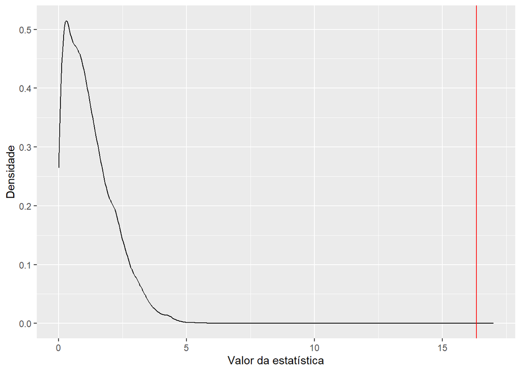

```r
# Gráfico da distribuição da diferênça entre as médias e a posição da diferenca entre a media real em vermelho em relação a distribuição
ggplot(data = results, aes(x = estatistica)) +
  geom_density() +
  geom_vline(xintercept = diff_media,
             color = "red") +
  xlim(0, 17) +
  xlab("Valor da estatística") +
  ylab("Densidade")
```

Podemos perceber que o valor é observado é bem extremo, logo podemos assumir que existe uma diferenca de medias entre os grupos

##### b) Obtenha o estimador de máxima verossimilhança de $\alpha$ e $\beta$ considerando o modelo proposto. Dica: Use a função `optim` do `R` para achar o ponto que maximiza a log-verossimilhança.

```r
# Variáveis
intercepto <- 1
temperatura <- dados2$Temperatura
sucessos <- dados2$Sucessos

logistica <- function(eta) exp(eta)
# Função para estimação dos parâmetros
log_verossimilhanca <- function(parametros, t, y) {
  eta <- t %*% parametros
  lambda <- logistica(eta)
  soma <- sum(dpois(y, lambda, log = TRUE))
  return(soma)
}

parametros_iniciais <- c(0, 0)
ajuste <- optim(parametros_iniciais, function(p) -log_verossimilhanca(p, t = cbind(intercepto, temperatura), y = sucessos),
                hessian = TRUE)
# Parâmetros estimados
parametros_est <- ajuste$par
parametros_est
```

```
## [1] 1.98571963 0.08171069
```

```r
# Modelo linear generalizado
mod <- glm(Sucessos ~ Temperatura, data = dados2, family=poisson())
tidy(mod)
```

```
## # A tibble: 2 × 5
##   term        estimate std.error statistic   p.value
##   <chr>          <dbl>     <dbl>     <dbl>     <dbl>
## 1 (Intercept)   1.99     0.0210       94.4 0
## 2 Temperatura   0.0817   0.00283      28.9 1.85e-183
```

Comparando os resultados podemos observar que os parametros estao bem proximos do esperado

##### c) Estime a distribuição de probabilidade do número de sucessos previstos para um dia em que a temperatura seja de 15 graus.

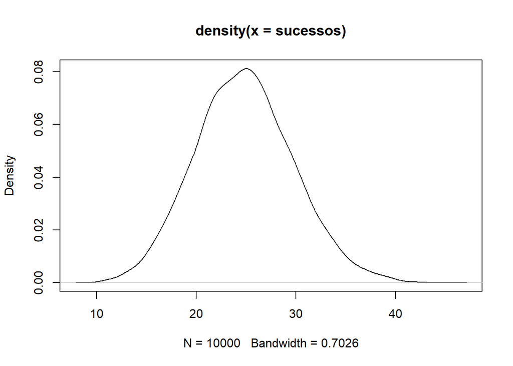

```r
# alpha e beta estimados
a <- parametros_est[1]
b <- parametros_est[2]
# Distribuição de n = 1000 observações geradas a partir do alpha e beta estimados para uma temperatura de 15 graus
sucessos <- rpois(n,exp(a + b * 15))

# Distribuição dos sucessos gerados
plot(density(sucessos))
```

##### d) Construa um intervalo de confiança de $95\%$ para $\exp({\beta})$ a partir do método de bootstrap paramétrico. Interprete o resultado considerando o contexto dos dados. Dica: calcule o aumento percentual da média esperada quando a temperatura aumenta em 1 grau Celsio.

```r
# Número de simulações
m <- 1000

# Variaveis
t <- dados2$Temperatura
y <- dados2$Sucessos
n <- nrow(dados2)

# Simulação
results <- unlist(lapply(1:m, function(amostra) {
  lambda <- exp(a + b * t)
  y.sim <- rpois(n, lambda)
  lambda2 <- exp(a + b * (t + 1))
  y.sim2 <- rpois(n, lambda2)
  log(mean(y.sim2) / mean(y.sim))
}))

# Intervalo de confiança para Beta com 5% de confiança
ic <- quantile(results, probs = c(0.025, 0.5, 0.975))
ic
```

```
##       2.5%        50%      97.5%
## 0.04457929 0.08294272 0.12120441
```

Como o beta ela representa a taxa de alteracao quando se aumenta a temperatura em uma unidade. Na nossa simulacao podemos encontrar esse valor e estimar uma intervalo de confianca para esse paramentro comparando as taxas de aumento.

##### e) Faça um diagnóstico do modelo via simulação. Para tanto, gere dados sintéticos usando o modelo obtido no item b), ajuste um novo modelo sobre os dados sintéticos e calcule o Erro quadrático médio (MSE). Repita esse procedimento 10000 vezes e compare os MSEs gerados com aquele do modelo obtido em b). Comente os resultados.

```r
# Ajuste do modelo original
mod <- lm(Sucessos ~ Temperatura, data = dados2, family = poisson())
t <- dados2$Temperatura
y.est <- fitted(mod)
sigma.est <- summary(mod)$sigma

# Parâmetros do modelo original
a <- coef(mod)[1]
b <- coef(mod)[2]

# Número de repetições e vetor para armazenar os MSEs
num_repeticoes <- 10000
mse_simulacao <- numeric(num_repeticoes)

# Função para simulação e cálculo dos MSEs
simular_e_calcular_mse <- function(i) {
  # Geração de dados sintéticos
  lambda <- exp(a + b * t)
  y.sim <- rpois(length(t), lambda)

  # Ajuste do modelo sobre os dados sintéticos
  mod_sintetico <- lm(y.sim ~ t, family = poisson())
  y.est_sintetico <- fitted(mod_sintetico)

  # Cálculo do MSE
  mean((y.sim - y.est_sintetico)^2)
}

# Simulação e cálculo dos MSEs usando lapply
mse_simulacao <- unlist(lapply(1:num_repeticoes, simular_e_calcular_mse))

# Cálculo do MSE original
mse_original <- mean((dados2$Sucessos - y.est)^2)

# Cálculo do MSE médio simulado
mse_simulacao_media <- mean(mse_simulacao)

# Comparação e comentários dos resultados
if (mse_simulacao_media > mse_original) {
  mensagem <- "Os MSEs simulados são maiores que o MSE original."
} else if (mse_simulacao_media < mse_original) {
  mensagem <- "Os MSEs simulados são menores que o MSE original."
} else {
  mensagem <- "Os MSEs simulados são iguais ao MSE original."
}

cat("MSE Original:", mse_original, "\n")
```

```
## MSE Original: 235.4943
```

```r
cat("MSE Médio Simulado:", mse_simulacao_media, "\n")
```

```
## MSE Médio Simulado: 1.872729e+14
```

```r
cat(mensagem)
```

```
## Os MSEs simulados são maiores que o MSE original.
```

Podemos perceber que o MSE dos dados sinteticos sao bem maiores que o MSE dos dados originais.

#### Questao 2)

Use o método de integração por Monte Carlo para estimar o volume de uma elipsoide definida por
$$\frac{x^2}{2} + \frac{y^2}{3} + \frac{z^2}{4} = 1.$$

```r
# Número de pontos simulados
m <- 100000

# Valor exato
a <- sqrt(2)
b <- sqrt(3)
c <- sqrt(4)

(v <- (4/3) * pi * a * b * c)
```

```
## [1] 20.5208
```

```r
# Simulação 3 dimensões
x <- runif(m, -a, a)
y <- runif(m, -b, b)
z <- runif(m, -c, c)

# Valores dentro da região do elipsoide
dentro <- x^2/2 + y^2/3 + z^2/4 < 1

8 * a * b * c * mean(dentro)
```

```
## [1] 20.56043
```